#### kilometer’s

a junk space

home

### これがカオス!?

単純な方程式の挙動をRで可視化し、カオスを体感してみましょう。

実数$r$を変化させた際の次の方程式の挙動を調べてみましょう。

$$x_{t+1}=r x_t (1- x_t) \tag{1}$$

### 準備

使うパッケージを読み込みましょう。

```r
library(tidyverse)
library(patchwork)
```

必要に応じて、事前にインストールしておいてください。

```r
install.packages("tidyverse")
install.packages("patchwork")
```

### 特定のrでの挙動を可視化する

この式の挙動を視覚的に理解できるように可視化してみましょう。

$x_t$を代入して$x_{t+1}$を得る関数`f`を用意します。

```r
f <- function(x, r){ r * x * (1 - x) }
```

適当な初期値を用意します。

```r
x0 <- 0.9
r <- 3.5
```

100 stepまで計算する事にします。

```r
t_max <- 100
```

逐次計算は`for`で回してしまいましょう。そのための関数を用意します。

```r
f_simulation <- function(r, x0, t_max){

  x_all <- NULL
  x <- x0

  for(t in 1:t_max){
    x <- f(x, r)  # 計算して
    x_all <- c(x_all, x)  # 繋げる
  }

  return(x_all)
}
```

結果をテーブルデータの形式に整えて取り扱いやすいtibble(data.frameの拡張版)に変換する関数を用意します。

```r
f_arrange <- function(x_all){

  t_max <- length(x_all)

  dat <-
    x_all %>%
    tibble(t = 2:(t_max+1), x_pre = .) %>%
    bind_rows(tibble(t = 1, x_pre = x0)) %>%
    arrange(t) %>%
    mutate(x_post = lead(x_pre)) %>%  # 1つずらしてx_{n+1}を作る
    filter(!is.na(x_post))  # NA行の除去

  return(dat)
}
```

さてお試し。

```r
dat <-
  f_simulation(r, x0, t_max) %>%
  f_arrange()

dat %>% head(5)
```

```
## # A tibble: 5 × 3
##       t x_pre x_post
##   <dbl> <dbl>  <dbl>
## 1     1 0.9    0.315
## 2     2 0.315  0.755
## 3     3 0.755  0.647
## 4     4 0.647  0.799
## 5     5 0.799  0.561
```

`x_pre`列が$x_t$、`x_post`列が$x_{t+1}$に相当します。

これを可視化します。まず、横軸に$t$、縦軸に$x_t$を取ったグラフを作成します。この作図関数を後でも使いたいので独自の関数`gg_line()`として定義しておきます。

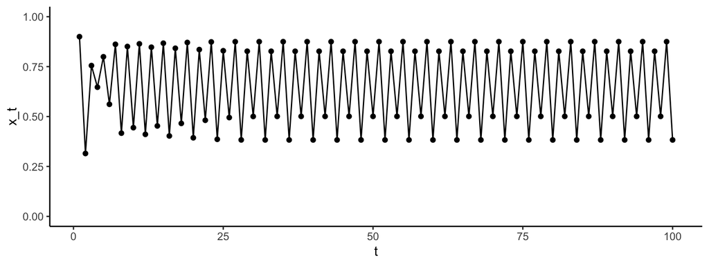

```r
# 作図関数
gg_line <- function(dat, t_upper = 100){
  ggplot(data = dat %>% filter(t <= t_upper)) +
  aes(x = t, y = x_pre) +
  geom_path() +
  geom_point() +
  scale_y_continuous(limits = c(0, 1)) +
  ylab("x_t")
}

# 作図
dat %>% gg_line()
```

明らかに4つの値を周期的に取るパタンに収束することが分かります。

別の作図として、横軸に$x_t$、縦軸に$x_{t+1}$を取ってみましょう。

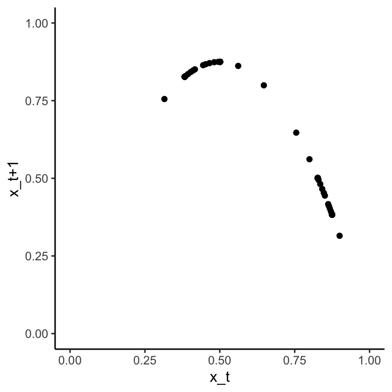

```r
ggplot(data = dat) +
  aes(x = x_pre, y = x_post) +
  geom_point() +
  scale_x_continuous(limits = c(0, 1)) +
  scale_y_continuous(limits = c(0, 1)) +
  xlab("x_t") + ylab("x_t+1")
```

二次関数上に点が分布しています。この関数は式(1)で表されるはずです。図に加えてみましょう。

曲線の座標を計算しておいて

```r
dat_line <-
  seq(0, 1, by = 0.01) %>%
  tibble(x_pre = .) %>%
  mutate(x_post = r * x_pre * (1 - x_pre))
```

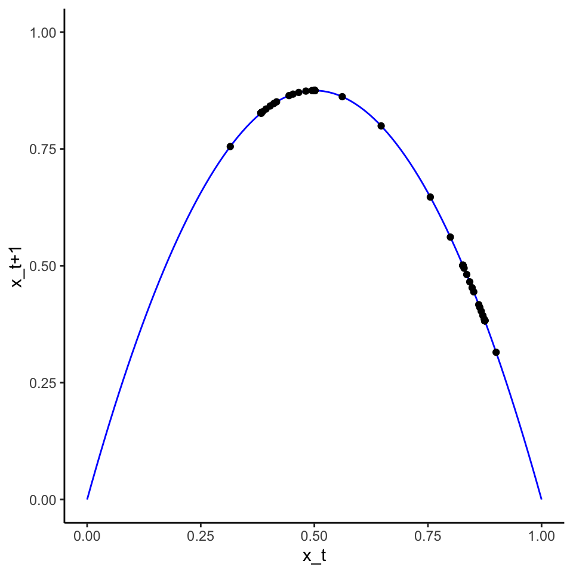

```r
ggplot(data = dat) +
  aes(x = x_pre, y = x_post) +
  geom_path(data = dat_line, color = "blue") +  # ←ここ
  geom_point() +
  scale_x_continuous(limits = c(0, 1)) +
  scale_y_continuous(limits = c(0, 1)) +
  xlab("x_t") + ylab("x_t+1")
```

良いですね。更にポイント同士を結び、step-by-stepで値が変化する様子を可視化してみましょう。ただし単に順番に点を結ぶのではなく、ある点が次のステップの点のx座標に利用されている様子が分かるように工夫しましょう。

これも後で使いまわしたいので、作図関数`gg_chaos()`を定義しておきます。

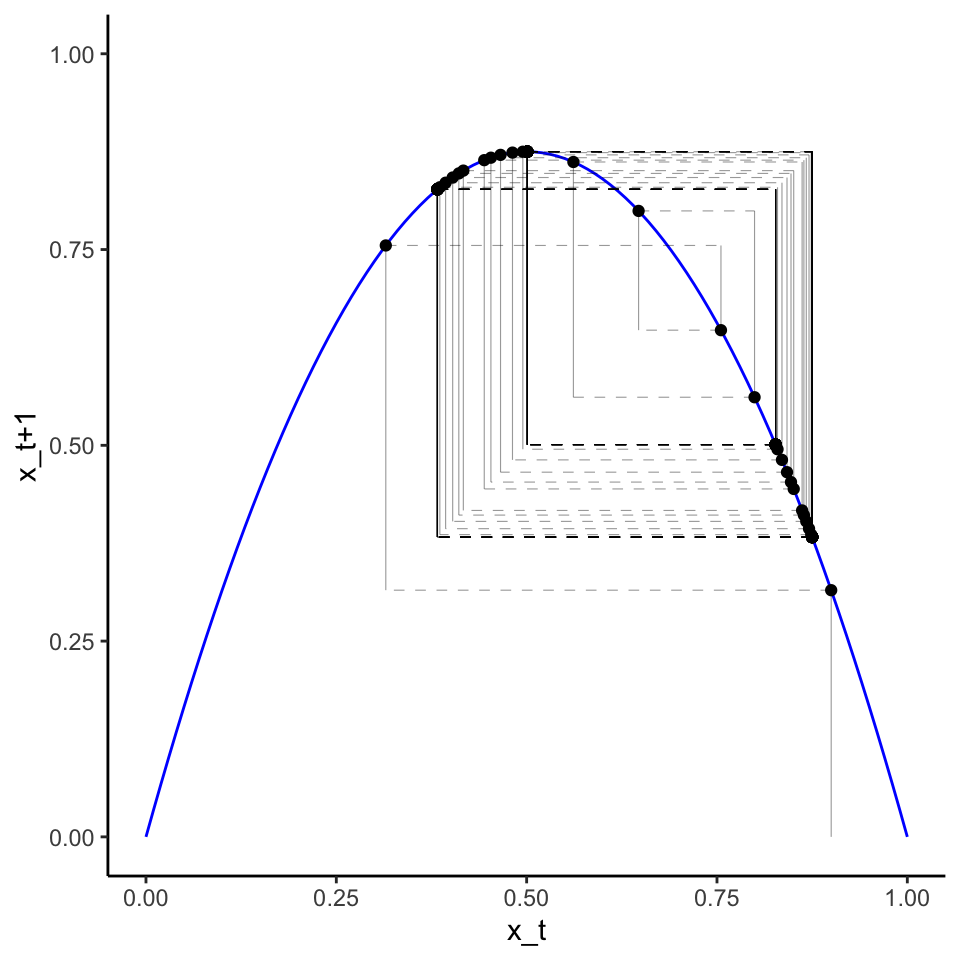

```r
# 作図関数
gg_chaos <- function(dat, dat_line){
  ggplot(data = dat) +
    aes(x = x_pre, y = x_post) +
    geom_path(data = dat_line, color = "blue") +  # 二次曲線
    # 最初(step 0)の縦線
    geom_segment(data = dat %>% filter(t == 1),
                 aes(xend = x_pre, yend = 0), alpha = 0.4, linewidth = 0.2) +
    # step 1 以降の縦線
    geom_segment(data = dat %>% filter(t > 1),
                 aes(xend = x_pre, yend = x_pre), alpha = 0.4, linewidth = 0.2) +
    # 横線
    geom_segment(aes(xend = x_post, yend = x_post), alpha = 0.4, linewidth = 0.2, linetype = "dashed") +
    # データポイント
    geom_point()+
    # スケール調整
    scale_x_continuous(limits = c(0, 1)) +
    scale_y_continuous(limits = c(0, 1)) +
    # 軸ラベル
    xlab("x_t") + ylab("x_t+1")
}

# 作図
dat %>%
  gg_chaos(dat_line)
```

良い感じですね。

### rを変化させる

例えば$r \in (1.5, 2, 2.5, 3, 3.5, 4)$とします。その時の応答を効率的に計算するには、畳み込みデータ(nested data)を上手く利用しましょう。

cf. [map脳になろう、もしくはnested dataのハンドリング](https://qiita.com/kilometer/items/7184904765fbf0f33f04)

```r
dat <-
  seq(1.5, 4, by = 0.5) %>%
  tibble(r = .) %>%
  mutate(data = map(
    r, ~ f_simulation(., x0, t_max) %>% f_arrange())
    ) %>%
  mutate(data_line = map(
    r, ~ tibble(x_pre = seq(0, 1, by = 0.01)) %>% mutate(x_post = .x * x_pre * (1 - x_pre)))
    )

dat
```

```
## # A tibble: 6 × 3
##       r data               data_line
##   <dbl> <list>             <list>
## 1   1.5 <tibble [100 × 3]> <tibble [101 × 2]>
## 2   2   <tibble [100 × 3]> <tibble [101 × 2]>
## 3   2.5 <tibble [100 × 3]> <tibble [101 × 2]>
## 4   3   <tibble [100 × 3]> <tibble [101 × 2]>
## 5   3.5 <tibble [100 × 3]> <tibble [101 × 2]>
## 6   4   <tibble [100 × 3]> <tibble [101 × 2]>
```

この`data`列に格納されているのが、それぞれの`r`に対応するシミュレーションの結果です。`data_line`が青色の曲線のための数値ですね。

このまま先ほど作った`gg_chaos()`関数で作図してしまいます。

```r
dat_g <-
  dat %>%
  mutate(g = map2(data, data_line, ~ gg_chaos(.x, .y))) %>%
  mutate(g = map2(g, r, ~ .x + ggtitle(str_c("r=", .y))))

dat_g
```

```
## # A tibble: 6 × 4
##       r data               data_line          g
##   <dbl> <list>             <list>             <list>
## 1   1.5 <tibble [100 × 3]> <tibble [101 × 2]> <gg>
## 2   2   <tibble [100 × 3]> <tibble [101 × 2]> <gg>
## 3   2.5 <tibble [100 × 3]> <tibble [101 × 2]> <gg>
## 4   3   <tibble [100 × 3]> <tibble [101 × 2]> <gg>
## 5   3.5 <tibble [100 × 3]> <tibble [101 × 2]> <gg>
## 6   4   <tibble [100 × 3]> <tibble [101 × 2]> <gg>
```

この`g`列にグラフが入っているので`wrap_plots()`関数を使って1つのグラフにまとめます。

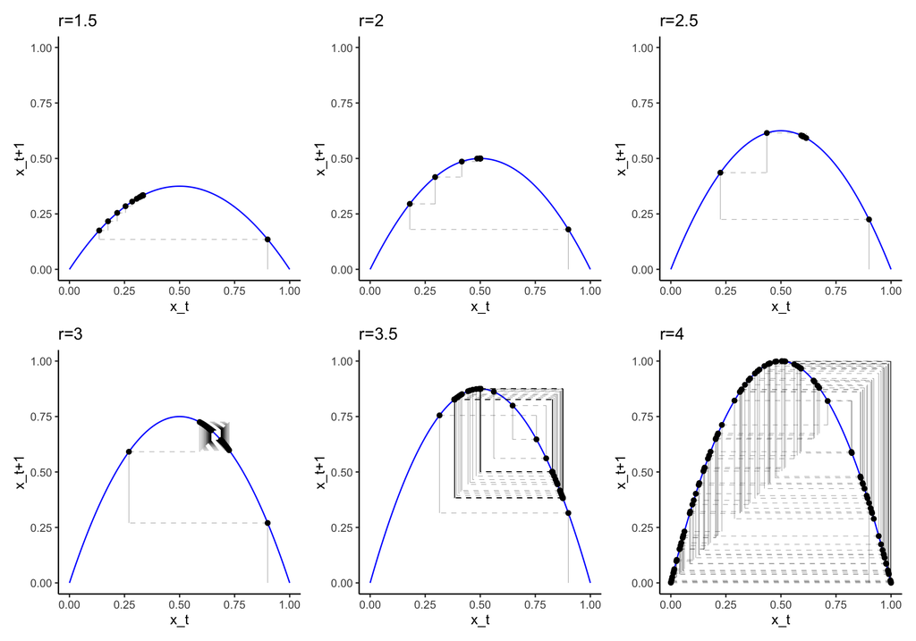

```r
dat_g$g %>% wrap_plots()
```

$x_t$の時系列も同じ方法で描画してみましょう。

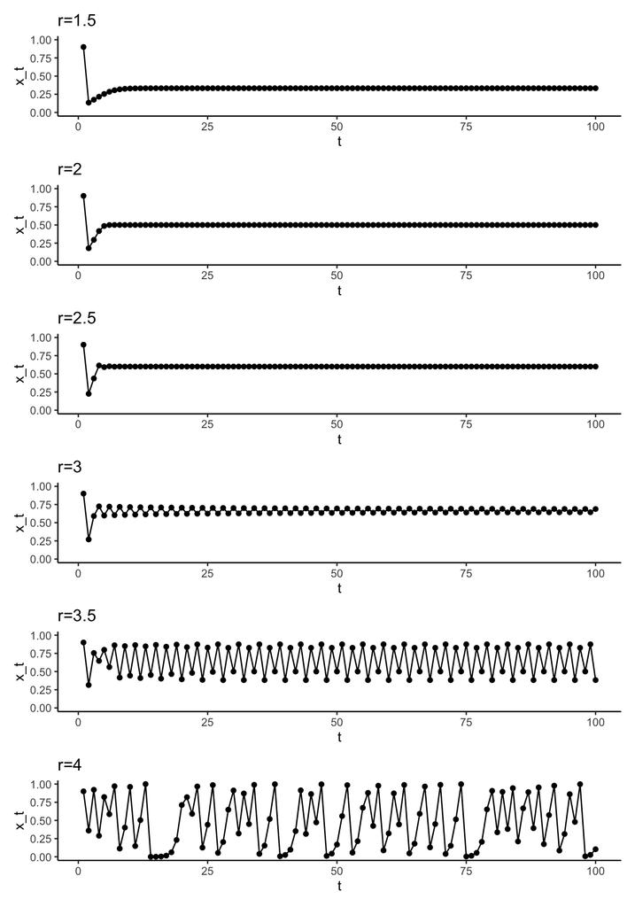

```r
dat_g %>%
  mutate(g_line = map(data, gg_line)) %>%
  mutate(g_line = map2(g_line, r, ~ .x + ggtitle(str_c("r=", .y)))) %>%
  .$g_line %>%
  wrap_plots(ncol = 1)
```

### rに応じたxの収束性を可視化する

$r$をもっと細かく変化させた時に、step 300から500の$x_t$の取り得る値を可視化してみましょう。

```r
dat <-
  tibble(r = seq(2.5, 4, by = 0.005)) %>%
  mutate(data = map(r, ~ f_simulation(., x0, t_max = 500) %>% f_arrange())) %>%
  mutate(r = round(r, 3)) %>%
  unnest(data)
```

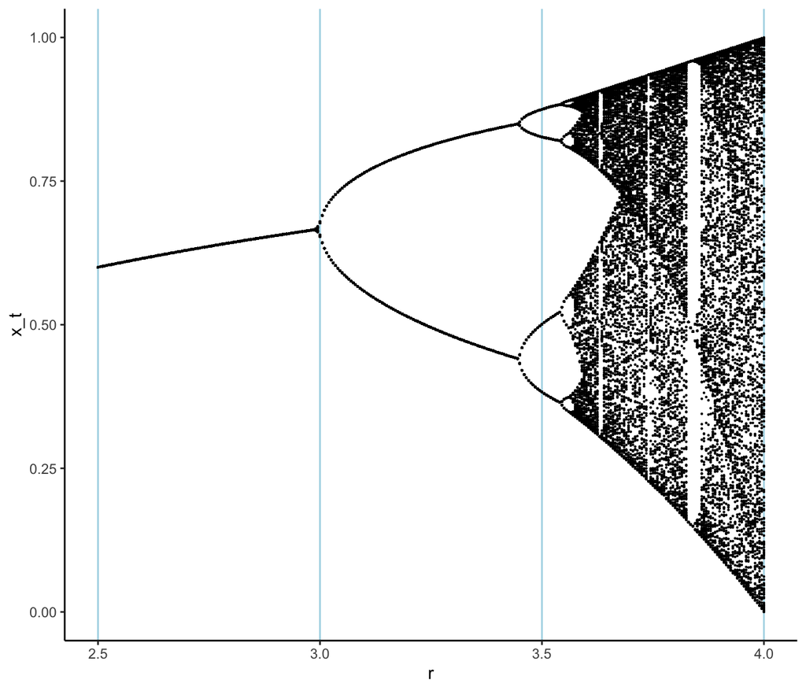

```r
dat %>%
  filter(t >= 300) %>%
  ggplot() +
  aes(r, x_pre) +
  geom_vline(xintercept = seq(2.5, 4, by = 0.5), color = "lightblue") +
  geom_point(size = 0.1) +
  ylab("x_t")
```

美しいグラフが描けました。収束性は単純に拡大するのではなく、ところどころ極端な収束を見せることがあるようです。例えば$r=3.8$ぐらいのところで3つの値に収束する傾向があるようです。細かく値を変化させながら、この範囲の$r$の値がいくつかを調べてみると、$r \simeq 3.83$が該当しました。

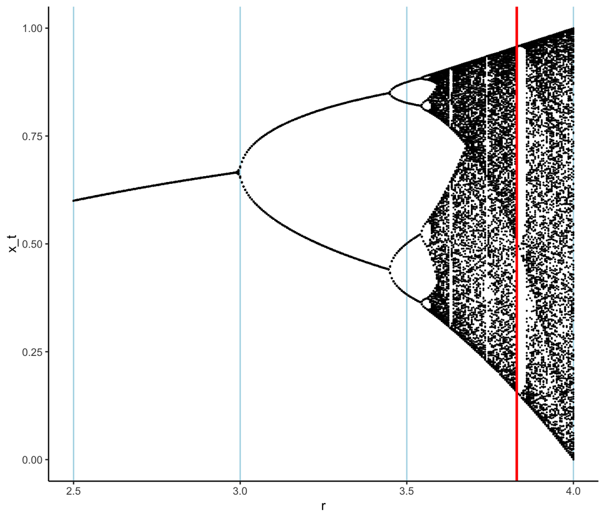

```r
dat %>%
  filter(t >= 300) %>%
  ggplot() +
  aes(r, x_pre) +
  geom_vline(xintercept = seq(2.5, 4, by = 0.5), color = "lightblue") +
  geom_point(size = 0.1)+
  geom_vline(xintercept = 3.83, color = "red", linewidth = 1)+
  ylab("x_t")
```

そこで、その近傍で$x_t$の時系列プロットを描いてみると…

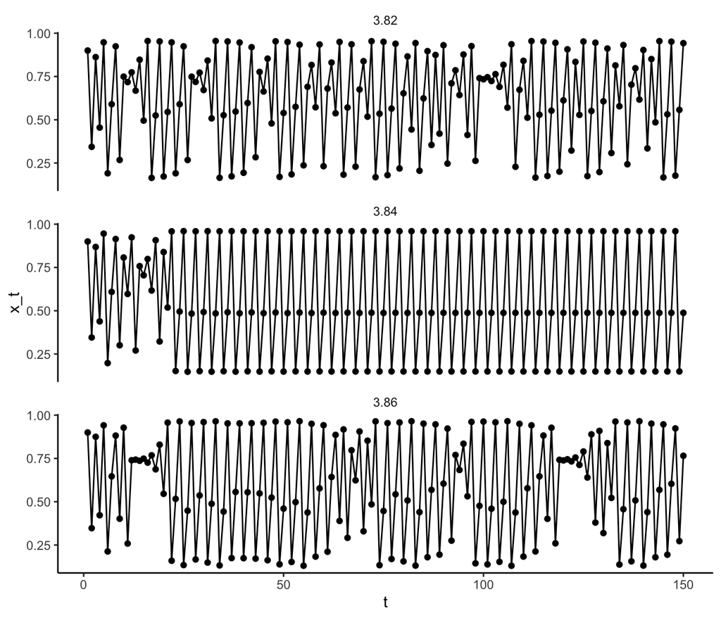

```r
dat %>%
  filter(t <= 150) %>%
  filter(r %in% c(3.82, 3.84, 3.86)) %>%
  ggplot() +
  aes(t, x_pre) +
  geom_point() +
  geom_path() +
  facet_wrap(~r, ncol = 1)+
  ylab("x_t")
```

$r$の値を僅かに変更しているだけですが、$r$が特定の値になった時だけ突然に系全体が3つの値に収束する様子が見て取れます。

### 補足

微分方程式をRで取り扱う方法は以下でも紹介しています。

cf. [{deSolve} 微分方程式 de オトナダマシ](https://qiita.com/kilometer/items/f63b9ee24d3eb06cf531)

#### 謝辞

本記事は統計数理研究所の公開講座[「カオス農学実践編―トラクタのカオス動力学と農作業安全対策―」](https://www.ism.ac.jp/lectures/2023b.html)にて講師の酒井憲司先生が取り上げていたトピックの一部をRで再現したものです。大変興味深いご講義をありがとうございました。感謝申し上げます。